# Beach vs. Mountains Preference

### Graph Description

> This graph shows the frequency of each education level colored by beach vs mountain preference. We can see that there is an equal amount of people in each category. This is interesting because if this dataset were to reflect the real world then there would be a much more pronounced difference between the number of people with a highschool education and even bachelor to those with a doctorate. More than likely we would see the number of people dwindle as the difficulty of obtaining the respective education level increases. We can also see that the distribution of preference between these two is also even telling us that whether or not someone has a certain level of education does not affect their preference.

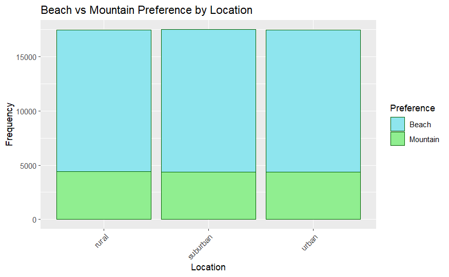

```r
Beach_vs_mountain %>%
  ggplot(aes(x = Location, fill = factor(Preference))) +
  geom_bar(position = "stack", color = "darkgreen") +
  labs(
    title = "Beach vs Mountain Preference by Location",
    x = "Location",
    y = "Frequency",
    fill = "Preference") +
  scale_fill_manual(values = c("cadetblue2", "lightgreen"), labels = c("Beach", "Mountain")) +
  theme(axis.text.x = element_text(angle = 45, hjust = 1))
```

### Graph Description

> This graph shows the Frequency of location colored by beach vs mountain preference. We can see that the split between people who live in each respective location type is an even split. We can also see that the distribution of preference between these three is also even telling us that whether or not someone lives in a certain location does not affect their preference. This is interesting because it is unlikely that there would be an even split between location types if the dataset reflected real-world conditions. This is because though the US is quite spread out many people are still concentrated in urban and suburban areas which would lead to a lower percentage of people living in rural areas.

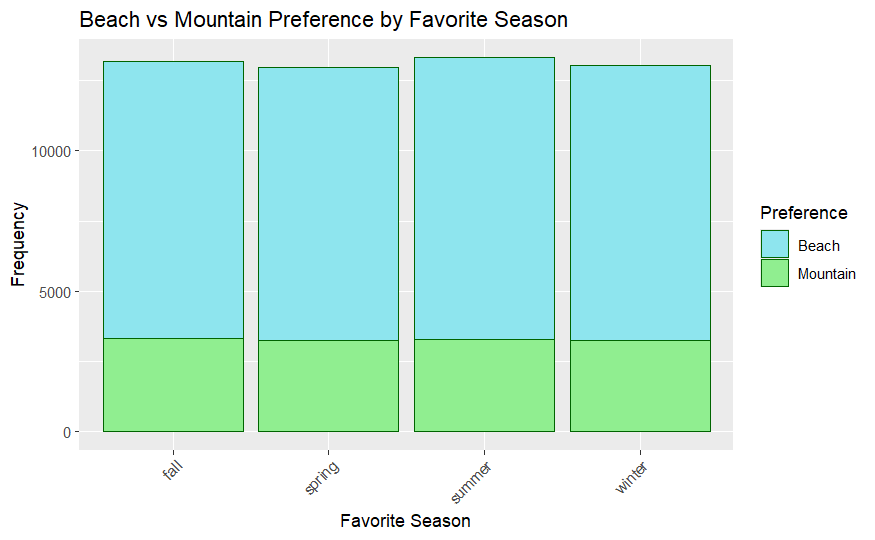

```r
Beach_vs_mountain %>%
  ggplot(aes(x = Favorite_Season, fill = factor(Preference))) +
  geom_bar(position = "stack", color = "darkgreen") +
  labs(
    title = "Beach vs Mountain Preference by Favorite Season",
    x = "Favorite Season",
    y = "Frequency",
    fill = "Preference") +
  scale_fill_manual(values = c("cadetblue2", "lightgreen"), labels = c("Beach", "Mountain")) +
  theme(axis.text.x = element_text(angle = 45, hjust = 1))
```